# **Analysis of House Sale and Rent Cost in Udine**

## **Project of Geospatial Analysis and Representation for Big Data**

### *Daniele Passabì, 221229*

## **Aim**

In this notebook we will perform a *geospatial analysis* of the average house price in Udine, both for buying and renting.

Our aim is to understand whether the average price of a municipality also depends on neighbouring municipalities.

## **Import Libraries**

We import the packages needed for data analysis and visualisation.

```r
library(dplyr)    # data manipulation
library(rgdal)    # import and store a shapefile in R
library(spdep)    # analysis of spatial dependence
library(ggplot2)  # create visualizations

print("> Libraries Imported")
```

```
## [1] "> Libraries Imported"
```

## **Import Data**

We first import the shapefile of all the municipalities in Italy.

```r
# import shapefile
italy_municipalities = readOGR("../data/Com01012021_g","Com01012021_g_WGS84")
# convert epsg:4326
italy_municipalities = spTransform(italy_municipalities, CRS("+init=epsg:4326"))

# show sample
head(italy_municipalities@data)
```

|  | COD_RIP | COD_REG | COD_PROV | COD_CM | COD_UTS | PRO_COM | PRO_COM_T | COMUNE | COMUNE_A | CC_UTS | Shape_Leng | Shape_Area |
| --- | --- | --- | --- | --- | --- | --- | --- | --- | --- | --- | --- | --- |
| 0 | 1 | 1 | 1 | 201 | 201 | 1001 | 001001 | AgliÃ¨ | NA | 0 | 16097.85 | 13306962 |
| 1 | 1 | 1 | 1 | 201 | 201 | 1002 | 001002 | Airasca | NA | 0 | 16684.22 | 15953529 |
| 2 | 1 | 1 | 1 | 201 | 201 | 1003 | 001003 | Ala di Stura | NA | 0 | 29892.67 | 45751888 |
| 3 | 1 | 1 | 1 | 201 | 201 | 1004 | 001004 | Albiano d'Ivrea | NA | 0 | 16192.66 | 11033555 |
| 4 | 1 | 1 | 1 | 201 | 201 | 1006 | 001006 | Almese | NA | 0 | 16077.25 | 17717104 |
| 5 | 1 | 1 | 1 | 201 | 201 | 1007 | 001007 | Alpette | NA | 0 | 8909.40 | 5321039 |

We filter and keep only the Udine municipalities. They must be 134.

```r
# Note: 30 is the Province Code for Udine

udine_municipalities = italy_municipalities[italy_municipalities$COD_PROV == 30,]
udine_municipalities@data
```

|  | COD_RIP | COD_REG | COD_PROV | COD_CM | COD_UTS | PRO_COM | PRO_COM_T | COMUNE | COMUNE_A | CC_UTS | Shape_Leng | Shape_Area |
| --- | --- | --- | --- | --- | --- | --- | --- | --- | --- | --- | --- | --- |
| 3600 | 2 | 6 | 30 | 0 | 30 | 30001 | 030001 | Aiello del Friuli | NA | 0 | 14834.499 | 12959541 |
| 3601 | 2 | 6 | 30 | 0 | 30 | 30002 | 030002 | Amaro | NA | 0 | 24860.370 | 33307339 |
| 3602 | 2 | 6 | 30 | 0 | 30 | 30003 | 030003 | Ampezzo | NA | 0 | 52991.788 | 73309083 |
| 3603 | 2 | 6 | 30 | 0 | 30 | 30004 | 030004 | Aquileia | NA | 0 | 37098.776 | 37301289 |
| 3604 | 2 | 6 | 30 | 0 | 30 | 30005 | 030005 | Arta Terme | NA | 0 | 34418.171 | 42648480 |
| 3605 | 2 | 6 | 30 | 0 | 30 | 30006 | 030006 | Artegna | NA | 0 | 14416.165 | 11595261 |
| 3606 | 2 | 6 | 30 | 0 | 30 | 30007 | 030007 | Attimis | NA | 0 | 27072.533 | 33299020 |
| 3607 | 2 | 6 | 30 | 0 | 30 | 30008 | 030008 | Bagnaria Arsa | NA | 0 | 26786.196 | 19271625 |
| 3608 | 2 | 6 | 30 | 0 | 30 | 30009 | 030009 | Basiliano | NA | 0 | 33111.398 | 42892453 |
| 3609 | 2 | 6 | 30 | 0 | 30 | 30010 | 030010 | Bertiolo | NA | 0 | 25921.587 | 26344596 |

[output cut: 124 more lines]

Let’s visualize the content of `udine_municipalities`.

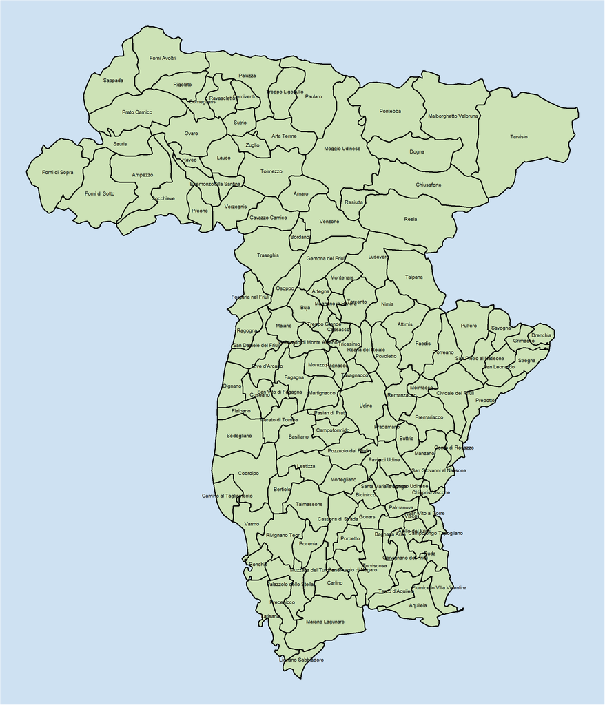

```r
par(mar=c(0,0,0,0))

# create base plot
plot(
  udine_municipalities,
  col = "#CDE2B6",
  bg = "#CEE1F2",
  lwd = 2
  )

# add name of municipality as text
text(
  coordinates(udine_municipalities),
  labels = udine_municipalities$COMUNE,
  cex = 0.6,
  col = "black"
  )
```

We now import data on house sales and rental costs and join them with our `udine_municipality` data.

```r
# we import the csv
house_sale_rent = read.csv("../data/udine_municipalities_house_cost.csv")

# we rename the column "Municipality" to "COMUNE", like the column in the shapefile
house_sale_rent = house_sale_rent %>%
  rename(COMUNE = Municipality)

# we join the data
udine_municipalities_with_house_cost = merge(udine_municipalities, house_sale_rent, by = "COMUNE")

# show results
udine_municipalities_with_house_cost@data %>%
  select(COMUNE, Sale, Rent)
```

|  | COMUNE | Sale | Rent |
| --- | --- | --- | --- |
| 1 | Aiello del Friuli | 946 | 6.74 |
| 2 | Amaro | 613 | 5.90 |
| 3 | Ampezzo | 608 | 6.02 |
| 4 | Aquileia | 968 | 6.99 |
| 5 | Arta Terme | 663 | 5.90 |
| 6 | Artegna | 993 | 6.25 |
| 7 | Attimis | 678 | 6.43 |
| 8 | Bagnaria Arsa | 879 | 6.57 |
| 9 | Basiliano | 876 | 6.55 |
| 10 | Bertiolo | 388 | 6.43 |

[output cut: 124 more lines]

## **Descriptive Spatial Statistics (Global Analysis)**

### **Centroids**

We need to assign each municipality a *unique spatial reference coordinate* to represent them.

We can calculate the *centroids* of the municipalities. Remember that:

The centroid or geometric center of a plane figure is the arithmetic mean position of all the points in the figure. [Wikipedia](https://en.wikipedia.org/wiki/Centroid)

```r
udine_mun_coords = coordinates(udine_municipalities_with_house_cost)
udine_mun_coords[0:5,]
```

```
##          [,1]     [,2]
## 3600 13.35357 45.87176
## 3601 13.10163 46.39042
## 3602 12.75062 46.41880
## 3603 13.36141 45.75603
## 3604 13.06493 46.47953
```

The centroids are arbitrary and may not fall within the polygon that defines them.

One classic example is the one of Liguria and its centroid:

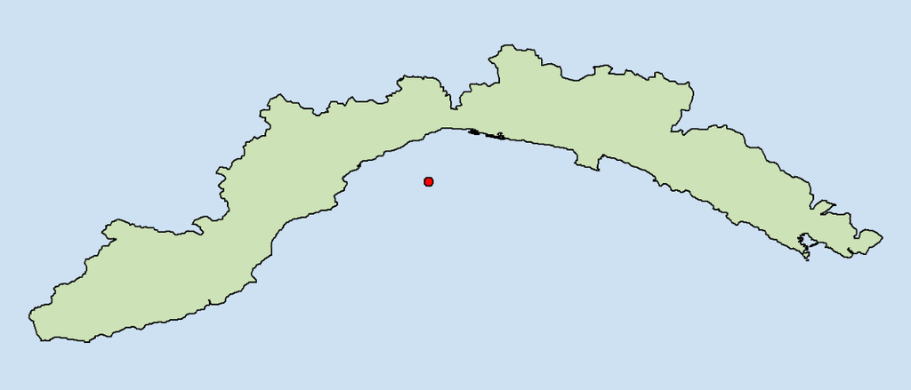

Let us visualise our centroids to ensure that there are no such problems.

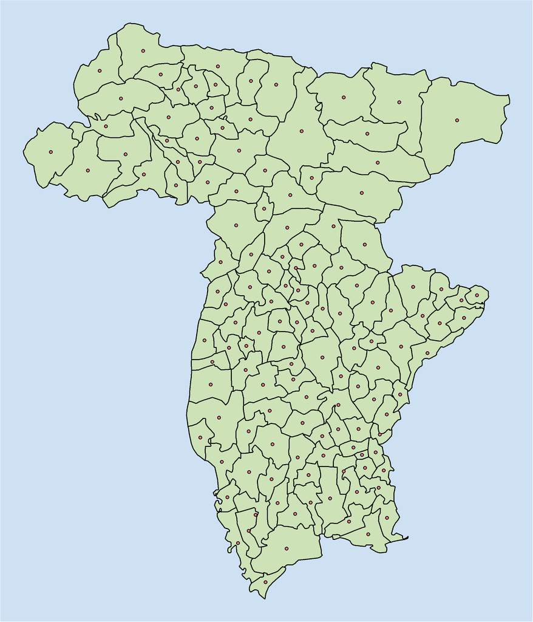

```r
par(mar=c(0,0,0,0))

plot(
  udine_municipalities_with_house_cost,
  col = "#CDE2B6",
  bg = "#CEE1F2",
  lwd = 2
  )

points(
  udine_mun_coords,
  cex = 1,
  col = "black",
  bg = "#EF798A",
  pch = 21,
  lwd = 1.5
  )
```

There are two municipalities where the centroid is outside the territory.

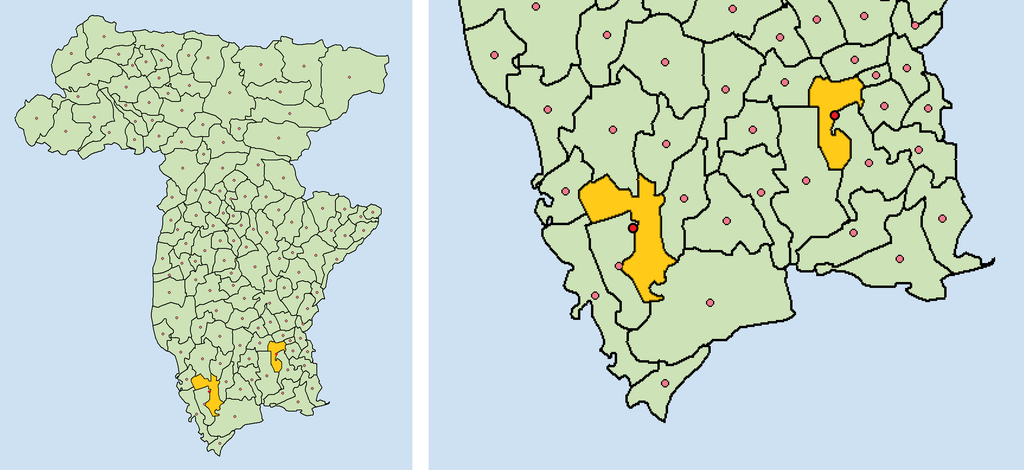

This should not be a major problem for our analysis, but it is wise to take this into account for the upcoming results.

### **Neighbourhood Relationships**

Using the centroids we can now define the neighbourhood relationships amongst the municipalities (spatial units).

Of the different possible definitions of neighbourhood we have seen:

- *k-nearest neighbours*
- *critical cut-off neighbourhood*
- *contiguity-based neighbourhood*

Let us explore them.

#### **A. k-nearest neighbours**

The k-nearest neighbours entails that two spatial units are considered neighbours if their distance is equal, or less than equal, to the smallest possible distance that can be found between all the units.

Following this definition of neighbourhood, each spatial unit will have the same number k of neighbours.

In R we can use the function `knn2nb`.

Note: we specify the parameter `longlat = True`, so that we do not use the Euclidean distance, but a distance that takes into account the fact that the Earth is not flat.

```r
# we try different values of k
knn_UD_mun_k1 = knn2nb(knearneigh(udine_mun_coords, k = 1, longlat = T))
knn_UD_mun_k2 = knn2nb(knearneigh(udine_mun_coords, k = 2, longlat = T))
knn_UD_mun_k3 = knn2nb(knearneigh(udine_mun_coords, k = 3, longlat = T))
knn_UD_mun_k4 = knn2nb(knearneigh(udine_mun_coords, k = 4, longlat = T))
```

Let’s visualize the results.

```r
# Create function for knn plot
plot_knn_res = function(shapefile, knn_obj, tie_color, k) {

  # set margins
  par(mar=c(0,0,2,0))

  # plot base map using shapefile
  plot(
    shapefile,
    col = "#CDE2B6",
    bg = "#CEE1F2",
    lwd = 1
  )

  # add custom title
  title(main = paste0("k = ",k))

  # plot over base map knn results
  plot(
    knn_obj,
    udine_mun_coords,
    add = T,
    col = tie_color,
    lwd = 2
    )
}
```

```r
#plot_knn_res(udine_municipalities_with_house_cost, knn_UD_mun_k1, "#EF798A", 1)
#plot_knn_res(udine_municipalities_with_house_cost, knn_UD_mun_k2, "#593F62", 2)
#plot_knn_res(udine_municipalities_with_house_cost, knn_UD_mun_k3, "#574AE2", 3)
#plot_knn_res(udine_municipalities_with_house_cost, knn_UD_mun_k4, "#21897E", 4)
```

*Note: to get a more comparable output, I manually merged the images.*

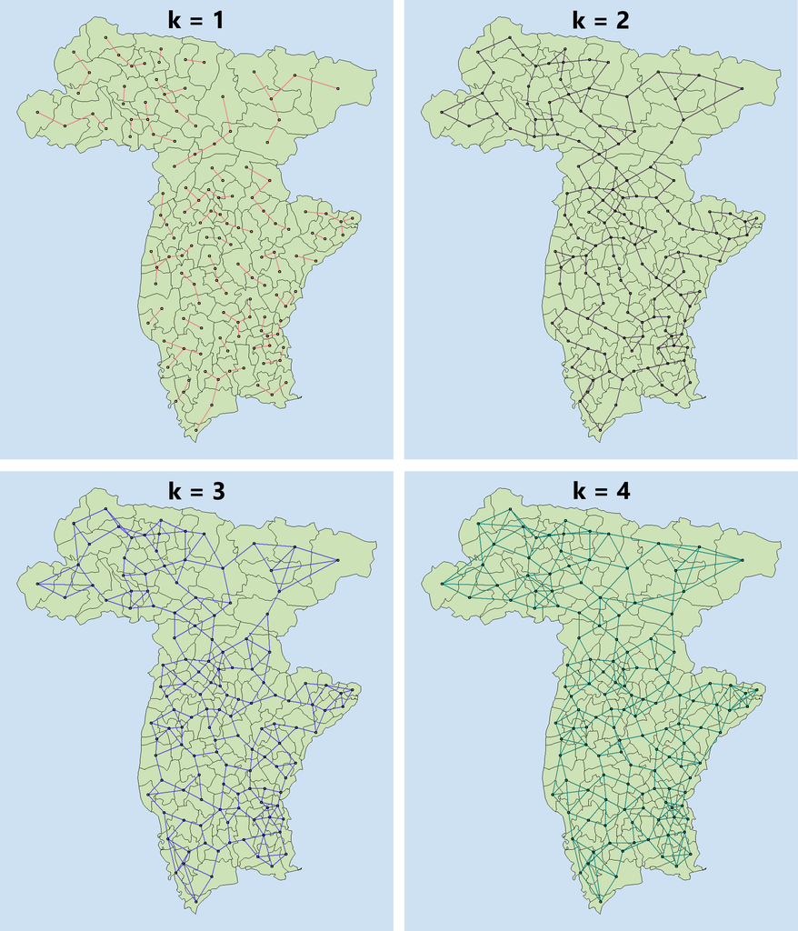

#### **B. Critical cut-off neighbourhood**

According to the critical cut-off criterion, two spatial units are considered to be neighbours if their distance is equal to, or less than equal to, a certain fixed distance, the critical cut-off.

It should be remembered, however, that this distance should allow all units to have at least one neighbour.

Thus, let us find the minimum distance required.

```r
knn_UD_mun_k1 = knn2nb(knearneigh(udine_mun_coords, k = 1, longlat = T))
max_mun_distance = max(unlist(nbdists(knn_UD_mun_k1, udine_mun_coords, longlat = T)))

message("The maximum distance between two municipalities is ", round(max_mun_distance,2), " km")
```

```
## The maximum distance between two municipalities is 11.72 km
```

Thus, the cut-off distance has to be greater than 11.72 (km).

```r
# We try different neighbourhood definitions for different values of the cut-off distance

dnb12 = dnearneigh(udine_mun_coords, 0, 12, longlat = T); message("dnb12"); dnb12
```

```
## dnb12
```

```
## Neighbour list object:
## Number of regions: 134
## Number of nonzero links: 1532
## Percentage nonzero weights: 8.531967
## Average number of links: 11.43284
```

```r
dnb16 = dnearneigh(udine_mun_coords, 0, 16, longlat = T); message("\ndnb16"); dnb16
```

```
##
## dnb16
```

```
## Neighbour list object:
## Number of regions: 134
## Number of nonzero links: 2620
## Percentage nonzero weights: 14.59122
## Average number of links: 19.55224
```

```r
dnb20 = dnearneigh(udine_mun_coords, 0, 20, longlat = T); message("\ndnb20"); dnb20
```

```
##
## dnb20
```

```
## Neighbour list object:
## Number of regions: 134
## Number of nonzero links: 3802
## Percentage nonzero weights: 21.17398
## Average number of links: 28.37313
```

```r
dnb24 = dnearneigh(udine_mun_coords, 0, 24, longlat = T); message("\ndnb24"); dnb24
```

```
##
## dnb24
```

```
## Neighbour list object:
## Number of regions: 134
## Number of nonzero links: 5066
## Percentage nonzero weights: 28.21341
## Average number of links: 37.80597
```

```r
# function to plot results of dnearneigh()

# Create function for knn plot
plot_dnb_res = function(shapefile, dnb_obj, tie_color, title) {

  # set margins
  par(mar=c(0,0,2,0))

  # plot base map using shapefile
  plot(
    shapefile,
    col = "#CDE2B6",
    bg = "#CEE1F2",
    lwd = 1
  )

  # add custom title
  title(main = title)

  # plot over base map knn results
  plot(
    dnb_obj,
    udine_mun_coords,
    add = T,
    col = tie_color,
    lwd = 1
    )
}
```

```r
#plot_dnb_res(udine_municipalities_with_house_cost, dnb12, "#EF798A", "d nearest neighbours, d = 12")
#plot_dnb_res(udine_municipalities_with_house_cost, dnb16, "#593F62", "d nearest neighbours, d = 16")
#plot_dnb_res(udine_municipalities_with_house_cost, dnb20, "#574AE2", "d nearest neighbours, d = 20")
#plot_dnb_res(udine_municipalities_with_house_cost, dnb24, "#21897E", "d nearest neighbours, d = 24")
```

*Note: as done previously, I am merging the images for more immediate comparison.*

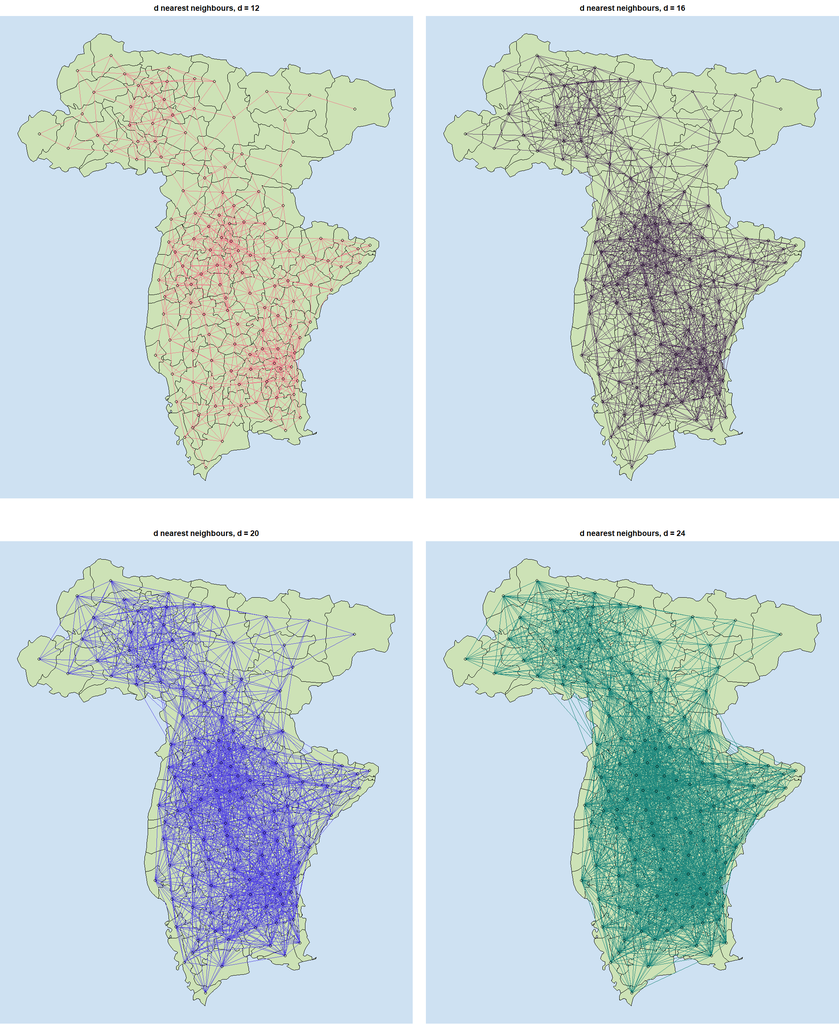

It is normal that as the critical cut-off increases, the number of connections increases.

In this case, however, even with the lowest value (12) of cut-off there seems to be a disproportion of connections between the north-eastern municipalities and the others.

This happens because the usual distance of the centroids tends to be much smaller than the maximum found. To make this concept clearer, we show a simple histogram of the distances.

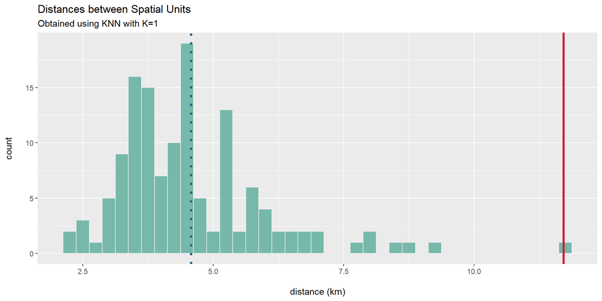

```r
# save the data in a df for ggplot
distance_vector = unlist(nbdists(knn_UD_mun_k1, udine_mun_coords, longlat = T))
distance_df = data.frame(distance_vector)

# show histogram of distances
ggplot(distance_df, aes(x = distance_vector)) +
  # create histogram
  geom_histogram(
    binwidth = 0.25,
    fill = "#69b3a2",
    color = "#e9ecef",
    alpha = 0.9
    ) +
  # add labels
  labs(
    title = "Distances between Spatial Units",
    subtitle = "Obtained using KNN with K=1",
    x = "\ndistance (km)",
    y = "count\n"
  ) +
  # add vertical lines for max distance and mean distance
  geom_vline(xintercept = max(distance_vector), color = "#C5283D", size = 1.25) +
  geom_vline(xintercept = mean(distance_vector), color = "#255F85", size = 1.25, linetype = "dotted")
```

As we can see from the picture, most of the distances are not too far from the average, which is 4.57 (represented by the blue dotted line).

However, the cutoff value we have to use is about 12 (red line), which is more than twice the average value of the distances. As a consequence, many neighbours are formed.

#### **C. Contiguity-based neighbourhood**

The neighbourhood criterion based on contiguity states that two spatial units are considered neighbours if they share a common border.

```r
# Note on "queen" parameter from the documentation
#   if TRUE, a single shared boundary point meets the contiguity condition,
#   if FALSE, more than one shared point is required

contnb_q = poly2nb(udine_municipalities_with_house_cost, queen = T)
```

```
## although coordinates are longitude/latitude, st_intersects assumes that they are planar
```

```r
contnb_q
```

```
## Neighbour list object:
## Number of regions: 134
## Number of nonzero links: 696
## Percentage nonzero weights: 3.876142
## Average number of links: 5.19403
```

Now we plot the results.

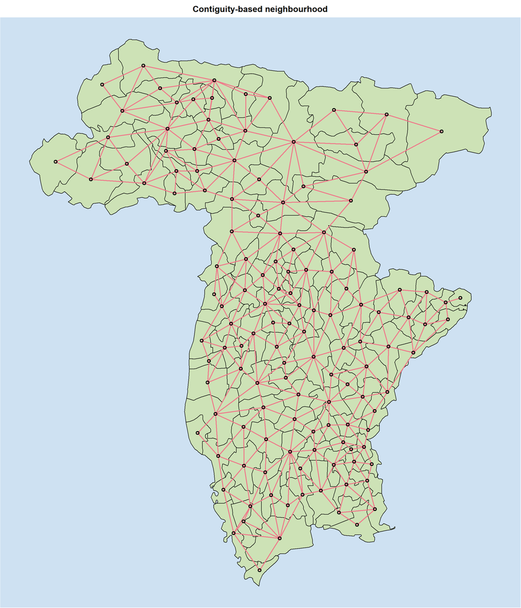

```r
par(mar=c(0,0,2,0))

# plot base map using shapefile
plot(
  udine_municipalities_with_house_cost,
  col = "#CDE2B6",
  bg = "#CEE1F2",
  lwd = 1
)

# add custom title
title(main = "Contiguity-based neighbourhood")

# plot results over base map
plot(
  contnb_q,
  udine_mun_coords,
  add = T,
  col = "#EF798A",
  lwd = 2
)
```

### **Defining Spatial Weights**

We have defined 9 neighbourhood relationships:

- 4 using *k-nearest neighbours*
- 4 using *critical cut-off neighbourhood*
- 1 using *contiguity-based neighbourhood*

Now we can create the spatial weights matrix, one for each neighbours list previously created.

```r
# k-nearest neighbours
knn_UD_mun_k1.listw = nb2listw(knn_UD_mun_k1, style = "W")
knn_UD_mun_k2.listw = nb2listw(knn_UD_mun_k2, style = "W")
knn_UD_mun_k3.listw = nb2listw(knn_UD_mun_k3, style = "W")
knn_UD_mun_k4.listw = nb2listw(knn_UD_mun_k4, style = "W")

# critical cut-off neighbourhood
dnb12.listw = nb2listw(dnb12, style = "W")
dnb16.listw = nb2listw(dnb16, style = "W")
dnb20.listw = nb2listw(dnb20, style = "W")
dnb24.listw = nb2listw(dnb24, style = "W")

# contiguity-based neighbourhood
contnb_q.listw = nb2listw(contnb_q, style = "W")
```

### **Moran’s I test of spatial autocorrelation**

The *Moran’s I test* is the most popular measure of (global) spatial autocorrelation of a variable.

It is given by:
$$I=\frac{n}{\sum_{i=1}^{n} \sum_{j=1}^{n} w_{i j}} \frac{\sum_{i=1}^{n} \sum_{j=1}^{n} w_{i j}\left(x_{i}-\bar{x}\right)\left(x_{j}-\bar{x}\right)}{\sum_{i=1}^{n}\left(x_{i}-\bar{x}\right)^{2}}$$

Its values range from:

- $-1 \rightarrow$ *negative* association
- $+1 \rightarrow$ *positive* association

If the value is close to $0$, that indicates absence of spatial autocorrelation.

Before we perform the *Moran’s I test*, we visually inspect our two variables “Sale” and “Rent”.

We first report the choropleths obtained in Python.

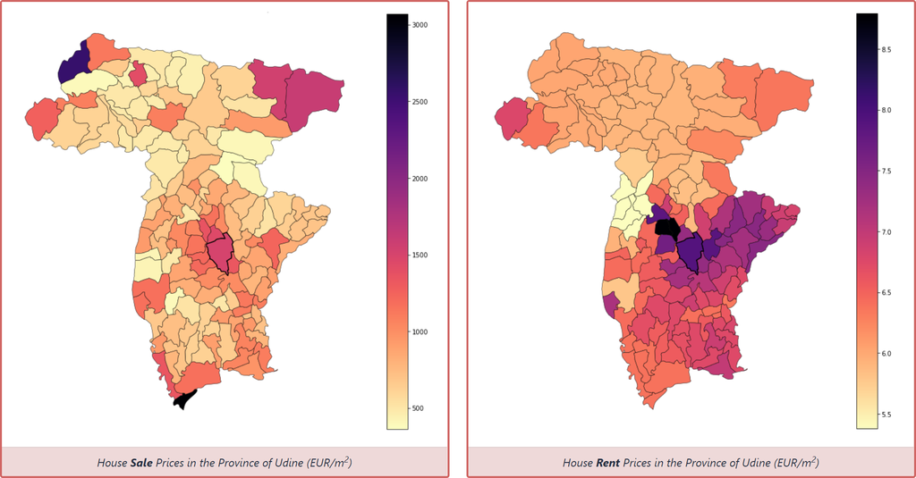

And now we visualize the quantile distribution of the variables.

```r
plot_quantile_distr = function(shapefile, col_name){

  # set margins
  par(mar=c(0,0,2,0))

  # obtain brks and colours based on provided column
  colours = grey((length(brks):2)/length(brks))

  if (col_name == "Sale") {
    brks = round(quantile(shapefile$Sale), digits = 3)
    colours = colours[findInterval(shapefile$Sale, brks, all.inside = TRUE)]
  } else if (col_name == "Rent") {
    brks = round(quantile(shapefile$Rent), digits = 3)
    colours = colours[findInterval(shapefile$Rent, brks, all.inside = TRUE)]
  } else {
    print("Error: unrecognised 'col_name' value provided. It must be 'Sale' or 'Rent'.")
  }

  # create plot
  plot(
    shapefile,
    col = colours
  )

  # custom title
  title(main = paste("House", col_name, "Prices in the Province of Udine"))
}
```

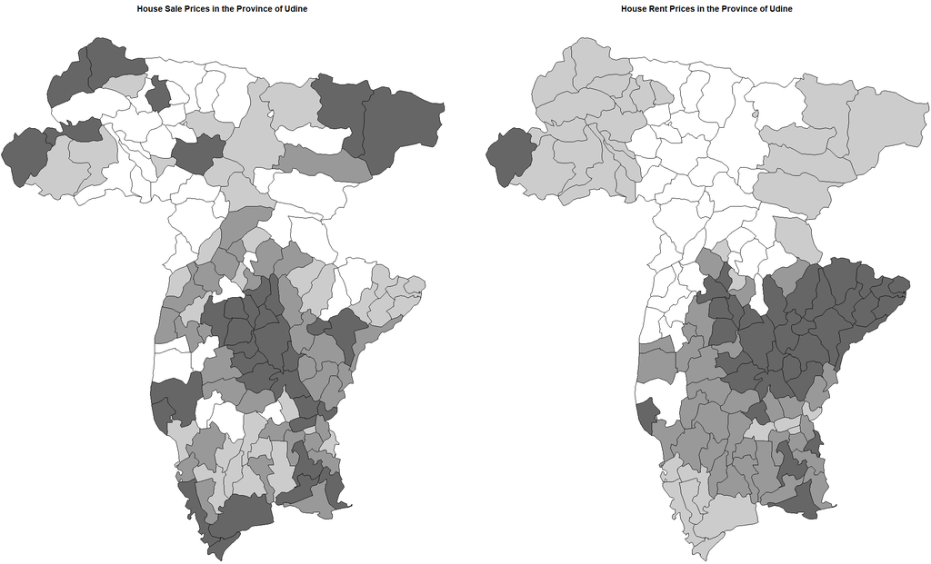

```r
#plot_quantile_distr(udine_municipalities_with_house_cost, "Sale")
#plot_quantile_distr(udine_municipalities_with_house_cost, "Rent")
```

We now apply to the test `Sale` and `Rent` with the different spatial weights matrix that we have.

```r
# we save all the weights (and the neighbourhood used) in a list
weights = list(
  list(knn_UD_mun_k1.listw, "k-nearest neighbours (k=1)"),
  list(knn_UD_mun_k2.listw, "k-nearest neighbours (k=2)"),
  list(knn_UD_mun_k3.listw, "k-nearest neighbours (k=3)"),
  list(knn_UD_mun_k4.listw, "k-nearest neighbours (k=4)"),
  list(dnb12.listw, "critical cut-off neighbourhood (d=12)"),
  list(dnb16.listw, "critical cut-off neighbourhood (d=16)"),
  list(dnb20.listw, "critical cut-off neighbourhood (d=20)"),
  list(dnb24.listw, "critical cut-off neighbourhood (d=24)"),
  list(contnb_q.listw, "contiguity-based neighbourhood")
)
```

### **Sale**

We test the `Sale` variable under the assumption of Normality and Randomization.

```r
# create arrays that will contain results
Neighbourhood = c()
Moran_I_stat_std_dev = c()
p_value = c()
Moran_I_statistic = c()
Expectation = c()
Variance = c()
Assumption = c()

# iterate over each weight and store results
for (w in weights) {

  for (rand in c(T,F)) {

    # execute test
    Neighbourhood = append(Neighbourhood, w[[2]])
    res = moran.test(udine_municipalities_with_house_cost$Sale, w[[1]], randomisation = rand)

    # save results
    Moran_I_stat_std_dev = append(Moran_I_stat_std_dev, round(as.numeric(res[[1]]),3))
    p_value = append(p_value, as.numeric(res[[2]]))
    Moran_I_statistic = append(Moran_I_statistic, round(as.numeric(res[[3]][1]),3))
    Expectation = append(Expectation, round(as.numeric(res[[3]][2]),3))
    Variance = append(Variance, round(as.numeric(res[[3]][3]),3))

    if (rand) {
      Assumption = append(Assumption, "Randomization")
    } else {
      Assumption = append(Assumption, "Normality")
    }
  }

}

# create df with results and show them
res_df = data.frame(Neighbourhood, Moran_I_stat_std_dev, p_value, Moran_I_statistic, Expectation, Variance, Assumption)
res_df
```

| Neighbourhood | Moran_I_stat_std_dev | p_value | Moran_I_statistic | Expectation | Variance | Assumption |
| --- | --- | --- | --- | --- | --- | --- |
| k-nearest neighbours (k=1) | 2.276 | 1.143100e-02 | 0.223 | -0.008 | 0.010 | Randomization |
| k-nearest neighbours (k=1) | 2.175 | 1.481142e-02 | 0.223 | -0.008 | 0.011 | Normality |
| k-nearest neighbours (k=2) | 3.364 | 3.842231e-04 | 0.246 | -0.008 | 0.006 | Randomization |
| k-nearest neighbours (k=2) | 3.215 | 6.525164e-04 | 0.246 | -0.008 | 0.006 | Normality |
| k-nearest neighbours (k=3) | 3.897 | 4.869084e-05 | 0.238 | -0.008 | 0.004 | Randomization |
| k-nearest neighbours (k=3) | 3.724 | 9.796470e-05 | 0.238 | -0.008 | 0.004 | Normality |
| k-nearest neighbours (k=4) | 4.514 | 3.174174e-06 | 0.239 | -0.008 | 0.003 | Randomization |
| k-nearest neighbours (k=4) | 4.314 | 8.005909e-06 | 0.239 | -0.008 | 0.003 | Normality |
| critical cut-off neighbourhood (d=12) | 6.181 | 3.181725e-10 | 0.225 | -0.008 | 0.001 | Randomization |
| critical cut-off neighbourhood (d=12) | 5.907 | 1.740156e-09 | 0.225 | -0.008 | 0.002 | Normality |

[output cut: 8 more lines]

Inspecting the results we can see that, in this case, the assumption of normality or randomization *does not* particularly affect the results.

- If we consider the results obtained through the k-nearest neighbourhood, we can see that the Moran I Statistic is always higher than $0.22$, regardless of the value of $k$.
- On the other hand, using the critical cut-off neighbourhood, the value starts at $0.225$ when we use the minimum value for $d$, but drops drastically close to $0$ when $d$ is higher.
- Finally, using the contiguity-based neighbourhood, the Moran I Statistic value is $0.256$.

From the results obtained, together with the extremely low p-values we can conclude that there is a *positive spatial autocorrelation*, although not too strong, for the `Sale` variable.

The low value of the Moran I Statistic in the case of critical cut-off neighbourhood could be due to the too large number of neighbours that are formed with too high $d$ values. So we do not consider it significant.

### **Rent**

We test the `Rent` variable under the assumption of Normality and Randomization.

```r
# create arrays that will contain results
Neighbourhood = c()
Moran_I_stat_std_dev = c()
p_value = c()
Moran_I_statistic = c()
Expectation = c()
Variance = c()
Assumption = c()

# iterate over each weight and store results
for (w in weights) {

  for (rand in c(T,F)) {

    # execute test
    Neighbourhood = append(Neighbourhood, w[[2]])
    res = moran.test(udine_municipalities_with_house_cost$Rent, w[[1]], randomisation = rand)

    # save results
    Moran_I_stat_std_dev = append(Moran_I_stat_std_dev, round(as.numeric(res[[1]]),3))
    p_value = append(p_value, as.numeric(res[[2]]))
    Moran_I_statistic = append(Moran_I_statistic, round(as.numeric(res[[3]][1]),3))
    Expectation = append(Expectation, round(as.numeric(res[[3]][2]),3))
    Variance = append(Variance, round(as.numeric(res[[3]][3]),3))

    if (rand) {
      Assumption = append(Assumption, "Randomization")
    } else {
      Assumption = append(Assumption, "Normality")
    }
  }

}

# create df with results and show them
res_df = data.frame(Neighbourhood, Moran_I_stat_std_dev, p_value, Moran_I_statistic, Expectation, Variance, Assumption)
res_df
```

| Neighbourhood | Moran_I_stat_std_dev | p_value | Moran_I_statistic | Expectation | Variance | Assumption |
| --- | --- | --- | --- | --- | --- | --- |
| k-nearest neighbours (k=1) | 7.622 | 1.245402e-14 | 0.795 | -0.008 | 0.011 | Randomization |
| k-nearest neighbours (k=1) | 7.578 | 1.753518e-14 | 0.795 | -0.008 | 0.011 | Normality |
| k-nearest neighbours (k=2) | 9.789 | 6.276050e-23 | 0.758 | -0.008 | 0.006 | Randomization |
| k-nearest neighbours (k=2) | 9.732 | 1.100719e-22 | 0.758 | -0.008 | 0.006 | Normality |
| k-nearest neighbours (k=3) | 10.919 | 4.692695e-28 | 0.708 | -0.008 | 0.004 | Randomization |
| k-nearest neighbours (k=3) | 10.855 | 9.432684e-28 | 0.708 | -0.008 | 0.004 | Normality |
| k-nearest neighbours (k=4) | 12.651 | 5.546628e-37 | 0.710 | -0.008 | 0.003 | Randomization |
| k-nearest neighbours (k=4) | 12.577 | 1.412989e-36 | 0.710 | -0.008 | 0.003 | Normality |
| critical cut-off neighbourhood (d=12) | 13.222 | 3.272328e-40 | 0.510 | -0.008 | 0.002 | Randomization |
| critical cut-off neighbourhood (d=12) | 13.145 | 9.081218e-40 | 0.510 | -0.008 | 0.002 | Normality |

[output cut: 8 more lines]

Also in the case of the variable `Rent` the assumption of normality or randomization *does not* particularly affect the results.

- With k-nearest neighbours the value of I goes from $0.795$, when $k = 1$ to $0.710$, when $k$ is higher ($4$).
- Using the critical cut-off neighbourhood the value of I falls to 0.51 if we consider the minimum value for $d$. As $d$ increases, the value of I decreases, until it reaches $0.352$ when $d = 24$.
- Finally, with the contiguity-based neighbourhood, the value of I is $0.71$.

The p-values are extremely low, which allows us to say that there is a strong *positive spatial autocorrelation* when we consider the `Rent` variable.